# Risk Factor Analysis

## Outcome Variable

**Outcome Variable:** sstunted

## Predictor Variables

**Intervention Variable:** vagbrth

**Adjustment Set:**

unadjusted

## Stratifying Variables

The analysis was stratified on these variable(s):

- agecat
- studyid
- country

## Data Summary

| agecat | studyid | country | A | n | nA | nAY0 | nAY1 |
| --- | --- | --- | --- | --- | --- | --- | --- |
| Birth | ki1000108-CMC-V-BCS-2002 | INDIA | 0 | 90 | 11 | 10 | 1 |
| Birth | ki1000108-CMC-V-BCS-2002 | INDIA | 1 | 90 | 79 | 77 | 2 |
| Birth | ki1000108-IRC | INDIA | 0 | 388 | 68 | 67 | 1 |
| Birth | ki1000108-IRC | INDIA | 1 | 388 | 320 | 305 | 15 |
| Birth | ki1017093c-NIH-Crypto | BANGLADESH | 0 | 19 | 1 | 1 | 0 |
| Birth | ki1017093c-NIH-Crypto | BANGLADESH | 1 | 19 | 18 | 18 | 0 |
| Birth | ki1126311-ZVITAMBO | ZIMBABWE | 0 | 13716 | 1162 | 1133 | 29 |
| Birth | ki1126311-ZVITAMBO | ZIMBABWE | 1 | 13716 | 12554 | 12150 | 404 |
| 3 months | ki1000108-CMC-V-BCS-2002 | INDIA | 0 | 362 | 25 | 23 | 2 |
| 3 months | ki1000108-CMC-V-BCS-2002 | INDIA | 1 | 362 | 337 | 306 | 31 |
| 3 months | ki1000108-IRC | INDIA | 0 | 407 | 69 | 62 | 7 |
| 3 months | ki1000108-IRC | INDIA | 1 | 407 | 338 | 309 | 29 |
| 3 months | ki1017093b-PROVIDE | BANGLADESH | 0 | 645 | 150 | 148 | 2 |
| 3 months | ki1017093b-PROVIDE | BANGLADESH | 1 | 645 | 495 | 487 | 8 |
| 3 months | ki1017093c-NIH-Crypto | BANGLADESH | 0 | 471 | 193 | 186 | 7 |
| 3 months | ki1017093c-NIH-Crypto | BANGLADESH | 1 | 471 | 278 | 267 | 11 |
| 3 months | ki1066203-TanzaniaChild2 | TANZANIA, UNITED REPUBLIC OF | 0 | 2265 | 201 | 200 | 1 |
| 3 months | ki1066203-TanzaniaChild2 | TANZANIA, UNITED REPUBLIC OF | 1 | 2265 | 2064 | 2040 | 24 |
| 3 months | ki1126311-ZVITAMBO | ZIMBABWE | 0 | 9123 | 797 | 761 | 36 |
| 3 months | ki1126311-ZVITAMBO | ZIMBABWE | 1 | 9123 | 8326 | 7842 | 484 |
| 6 months | ki1000108-CMC-V-BCS-2002 | INDIA | 0 | 369 | 25 | 23 | 2 |
| 6 months | ki1000108-CMC-V-BCS-2002 | INDIA | 1 | 369 | 344 | 304 | 40 |
| 6 months | ki1000108-IRC | INDIA | 0 | 407 | 69 | 64 | 5 |
| 6 months | ki1000108-IRC | INDIA | 1 | 407 | 338 | 314 | 24 |
| 6 months | ki1017093b-PROVIDE | BANGLADESH | 0 | 583 | 134 | 132 | 2 |
| 6 months | ki1017093b-PROVIDE | BANGLADESH | 1 | 583 | 449 | 437 | 12 |
| 6 months | ki1017093c-NIH-Crypto | BANGLADESH | 0 | 457 | 187 | 183 | 4 |
| 6 months | ki1017093c-NIH-Crypto | BANGLADESH | 1 | 457 | 270 | 258 | 12 |
| 6 months | ki1066203-TanzaniaChild2 | TANZANIA, UNITED REPUBLIC OF | 0 | 2005 | 189 | 189 | 0 |
| 6 months | ki1066203-TanzaniaChild2 | TANZANIA, UNITED REPUBLIC OF | 1 | 2005 | 1816 | 1797 | 19 |
| 6 months | ki1126311-ZVITAMBO | ZIMBABWE | 0 | 8228 | 707 | 682 | 25 |
| 6 months | ki1126311-ZVITAMBO | ZIMBABWE | 1 | 8228 | 7521 | 7200 | 321 |
| 9 months | ki1000108-CMC-V-BCS-2002 | INDIA | 0 | 366 | 24 | 21 | 3 |
| 9 months | ki1000108-CMC-V-BCS-2002 | INDIA | 1 | 366 | 342 | 298 | 44 |
| 9 months | ki1000108-IRC | INDIA | 0 | 407 | 69 | 64 | 5 |
| 9 months | ki1000108-IRC | INDIA | 1 | 407 | 338 | 309 | 29 |
| 9 months | ki1017093b-PROVIDE | BANGLADESH | 0 | 605 | 139 | 135 | 4 |
| 9 months | ki1017093b-PROVIDE | BANGLADESH | 1 | 605 | 466 | 445 | 21 |
| 9 months | ki1017093c-NIH-Crypto | BANGLADESH | 0 | 450 | 185 | 179 | 6 |
| 9 months | ki1017093c-NIH-Crypto | BANGLADESH | 1 | 450 | 265 | 253 | 12 |
| 9 months | ki1066203-TanzaniaChild2 | TANZANIA, UNITED REPUBLIC OF | 0 | 1770 | 168 | 165 | 3 |
| 9 months | ki1066203-TanzaniaChild2 | TANZANIA, UNITED REPUBLIC OF | 1 | 1770 | 1602 | 1570 | 32 |
| 9 months | ki1126311-ZVITAMBO | ZIMBABWE | 0 | 7609 | 640 | 610 | 30 |
| 9 months | ki1126311-ZVITAMBO | ZIMBABWE | 1 | 7609 | 6969 | 6633 | 336 |
| 12 months | ki1000108-CMC-V-BCS-2002 | INDIA | 0 | 368 | 25 | 20 | 5 |
| 12 months | ki1000108-CMC-V-BCS-2002 | INDIA | 1 | 368 | 343 | 265 | 78 |
| 12 months | ki1000108-IRC | INDIA | 0 | 406 | 70 | 63 | 7 |
| 12 months | ki1000108-IRC | INDIA | 1 | 406 | 336 | 309 | 27 |
| 12 months | ki1017093b-PROVIDE | BANGLADESH | 0 | 600 | 138 | 136 | 2 |
| 12 months | ki1017093b-PROVIDE | BANGLADESH | 1 | 600 | 462 | 428 | 34 |
| 12 months | ki1017093c-NIH-Crypto | BANGLADESH | 0 | 450 | 185 | 175 | 10 |
| 12 months | ki1017093c-NIH-Crypto | BANGLADESH | 1 | 450 | 265 | 249 | 16 |
| 12 months | ki1066203-TanzaniaChild2 | TANZANIA, UNITED REPUBLIC OF | 0 | 1424 | 137 | 134 | 3 |
| 12 months | ki1066203-TanzaniaChild2 | TANZANIA, UNITED REPUBLIC OF | 1 | 1424 | 1287 | 1257 | 30 |
| 12 months | ki1126311-ZVITAMBO | ZIMBABWE | 0 | 6691 | 550 | 516 | 34 |
| 12 months | ki1126311-ZVITAMBO | ZIMBABWE | 1 | 6691 | 6141 | 5737 | 404 |
| 18 months | ki1000108-CMC-V-BCS-2002 | INDIA | 0 | 369 | 25 | 17 | 8 |
| 18 months | ki1000108-CMC-V-BCS-2002 | INDIA | 1 | 369 | 344 | 243 | 101 |
| 18 months | ki1000108-IRC | INDIA | 0 | 405 | 69 | 65 | 4 |
| 18 months | ki1000108-IRC | INDIA | 1 | 405 | 336 | 306 | 30 |
| 18 months | ki1017093b-PROVIDE | BANGLADESH | 0 | 552 | 129 | 122 | 7 |
| 18 months | ki1017093b-PROVIDE | BANGLADESH | 1 | 552 | 423 | 373 | 50 |
| 18 months | ki1017093c-NIH-Crypto | BANGLADESH | 0 | 380 | 150 | 142 | 8 |
| 18 months | ki1017093c-NIH-Crypto | BANGLADESH | 1 | 380 | 230 | 210 | 20 |
| 18 months | ki1066203-TanzaniaChild2 | TANZANIA, UNITED REPUBLIC OF | 0 | 967 | 89 | 84 | 5 |
| 18 months | ki1066203-TanzaniaChild2 | TANZANIA, UNITED REPUBLIC OF | 1 | 967 | 878 | 843 | 35 |
| 18 months | ki1126311-ZVITAMBO | ZIMBABWE | 0 | 1692 | 141 | 116 | 25 |
| 18 months | ki1126311-ZVITAMBO | ZIMBABWE | 1 | 1692 | 1551 | 1282 | 269 |
| 24 months | ki1000108-CMC-V-BCS-2002 | INDIA | 0 | 372 | 25 | 16 | 9 |
| 24 months | ki1000108-CMC-V-BCS-2002 | INDIA | 1 | 372 | 347 | 233 | 114 |
| 24 months | ki1000108-IRC | INDIA | 0 | 409 | 69 | 66 | 3 |
| 24 months | ki1000108-IRC | INDIA | 1 | 409 | 340 | 302 | 38 |
| 24 months | ki1017093b-PROVIDE | BANGLADESH | 0 | 577 | 137 | 130 | 7 |
| 24 months | ki1017093b-PROVIDE | BANGLADESH | 1 | 577 | 440 | 398 | 42 |
| 24 months | ki1017093c-NIH-Crypto | BANGLADESH | 0 | 260 | 99 | 92 | 7 |
| 24 months | ki1017093c-NIH-Crypto | BANGLADESH | 1 | 260 | 161 | 147 | 14 |
| 24 months | ki1066203-TanzaniaChild2 | TANZANIA, UNITED REPUBLIC OF | 0 | 6 | 2 | 2 | 0 |
| 24 months | ki1066203-TanzaniaChild2 | TANZANIA, UNITED REPUBLIC OF | 1 | 6 | 4 | 3 | 1 |
| 24 months | ki1126311-ZVITAMBO | ZIMBABWE | 0 | 450 | 29 | 22 | 7 |
| 24 months | ki1126311-ZVITAMBO | ZIMBABWE | 1 | 450 | 421 | 299 | 122 |

The following strata were considered:

- agecat: 12 months, studyid: ki1000108-CMC-V-BCS-2002, country: INDIA
- agecat: 12 months, studyid: ki1000108-IRC, country: INDIA
- agecat: 12 months, studyid: ki1017093b-PROVIDE, country: BANGLADESH
- agecat: 12 months, studyid: ki1017093c-NIH-Crypto, country: BANGLADESH
- agecat: 12 months, studyid: ki1066203-TanzaniaChild2, country: TANZANIA, UNITED REPUBLIC OF
- agecat: 12 months, studyid: ki1126311-ZVITAMBO, country: ZIMBABWE
- agecat: 18 months, studyid: ki1000108-CMC-V-BCS-2002, country: INDIA
- agecat: 18 months, studyid: ki1000108-IRC, country: INDIA
- agecat: 18 months, studyid: ki1017093b-PROVIDE, country: BANGLADESH
- agecat: 18 months, studyid: ki1017093c-NIH-Crypto, country: BANGLADESH
- agecat: 18 months, studyid: ki1066203-TanzaniaChild2, country: TANZANIA, UNITED REPUBLIC OF
- agecat: 18 months, studyid: ki1126311-ZVITAMBO, country: ZIMBABWE
- agecat: 24 months, studyid: ki1000108-CMC-V-BCS-2002, country: INDIA
- agecat: 24 months, studyid: ki1000108-IRC, country: INDIA
- agecat: 24 months, studyid: ki1017093b-PROVIDE, country: BANGLADESH
- agecat: 24 months, studyid: ki1017093c-NIH-Crypto, country: BANGLADESH
- agecat: 24 months, studyid: ki1066203-TanzaniaChild2, country: TANZANIA, UNITED REPUBLIC OF
- agecat: 24 months, studyid: ki1126311-ZVITAMBO, country: ZIMBABWE
- agecat: 3 months, studyid: ki1000108-CMC-V-BCS-2002, country: INDIA
- agecat: 3 months, studyid: ki1000108-IRC, country: INDIA
- agecat: 3 months, studyid: ki1017093b-PROVIDE, country: BANGLADESH
- agecat: 3 months, studyid: ki1017093c-NIH-Crypto, country: BANGLADESH
- agecat: 3 months, studyid: ki1066203-TanzaniaChild2, country: TANZANIA, UNITED REPUBLIC OF
- agecat: 3 months, studyid: ki1126311-ZVITAMBO, country: ZIMBABWE
- agecat: 6 months, studyid: ki1000108-CMC-V-BCS-2002, country: INDIA
- agecat: 6 months, studyid: ki1000108-IRC, country: INDIA
- agecat: 6 months, studyid: ki1017093b-PROVIDE, country: BANGLADESH
- agecat: 6 months, studyid: ki1017093c-NIH-Crypto, country: BANGLADESH
- agecat: 6 months, studyid: ki1066203-TanzaniaChild2, country: TANZANIA, UNITED REPUBLIC OF
- agecat: 6 months, studyid: ki1126311-ZVITAMBO, country: ZIMBABWE
- agecat: 9 months, studyid: ki1000108-CMC-V-BCS-2002, country: INDIA
- agecat: 9 months, studyid: ki1000108-IRC, country: INDIA
- agecat: 9 months, studyid: ki1017093b-PROVIDE, country: BANGLADESH
- agecat: 9 months, studyid: ki1017093c-NIH-Crypto, country: BANGLADESH
- agecat: 9 months, studyid: ki1066203-TanzaniaChild2, country: TANZANIA, UNITED REPUBLIC OF
- agecat: 9 months, studyid: ki1126311-ZVITAMBO, country: ZIMBABWE
- agecat: Birth, studyid: ki1000108-CMC-V-BCS-2002, country: INDIA
- agecat: Birth, studyid: ki1000108-IRC, country: INDIA
- agecat: Birth, studyid: ki1017093c-NIH-Crypto, country: BANGLADESH
- agecat: Birth, studyid: ki1126311-ZVITAMBO, country: ZIMBABWE

### Dropped Strata

Some strata were dropped due to rare outcomes:

- agecat: Birth, studyid: ki1000108-CMC-V-BCS-2002, country: INDIA
- agecat: Birth, studyid: ki1000108-IRC, country: INDIA
- agecat: Birth, studyid: ki1017093c-NIH-Crypto, country: BANGLADESH
- agecat: 3 months, studyid: ki1000108-CMC-V-BCS-2002, country: INDIA
- agecat: 3 months, studyid: ki1017093b-PROVIDE, country: BANGLADESH
- agecat: 3 months, studyid: ki1066203-TanzaniaChild2, country: TANZANIA, UNITED REPUBLIC OF
- agecat: 6 months, studyid: ki1000108-CMC-V-BCS-2002, country: INDIA
- agecat: 6 months, studyid: ki1017093b-PROVIDE, country: BANGLADESH
- agecat: 6 months, studyid: ki1017093c-NIH-Crypto, country: BANGLADESH
- agecat: 6 months, studyid: ki1066203-TanzaniaChild2, country: TANZANIA, UNITED REPUBLIC OF
- agecat: 9 months, studyid: ki1000108-CMC-V-BCS-2002, country: INDIA
- agecat: 9 months, studyid: ki1017093b-PROVIDE, country: BANGLADESH
- agecat: 9 months, studyid: ki1066203-TanzaniaChild2, country: TANZANIA, UNITED REPUBLIC OF
- agecat: 12 months, studyid: ki1017093b-PROVIDE, country: BANGLADESH
- agecat: 12 months, studyid: ki1066203-TanzaniaChild2, country: TANZANIA, UNITED REPUBLIC OF
- agecat: 18 months, studyid: ki1000108-IRC, country: INDIA
- agecat: 24 months, studyid: ki1000108-IRC, country: INDIA
- agecat: 24 months, studyid: ki1066203-TanzaniaChild2, country: TANZANIA, UNITED REPUBLIC OF

## Methods Detail

We’re interested in the causal parameters $E[Y_a]$ for all values of $a \in \mathcal{A}$. These parameters represent the mean outcome if, possibly contrary to fact, we intervened to set all units to have $A=a$. Under the randomization and positivity assumptions, these are identified by the statistical parameters $\psi_a=E_W[E_{Y|A,W}(Y|A=a,W)]$. In addition, we’re interested in the mean of $Y$, $E[Y]$ under no intervention (the observed mean). We will estimate these parameters by using SuperLearner to fit the relevant likelihood factors – $E_{Y|A,W}(Y|A=a,W)$ and $p(A=a|W)$, and then updating our likelihood fit using a joint TMLE.

For unadjusted analyses ($W=\{\}$), initial likelihoods were estimated using Lrnr_glm to estimate the simple $E(Y|A)$ and Lrnr_mean to estimate $p(A)$. For adjusted analyses, a small library containing Lrnr_glmnet, Lrnr_xgboost, and Lrnr_mean was used.

Having estimated these parameters, we will then use the delta method to estimate relative risks and attributable risks relative to a prespecified baseline level of $A$.

# Results Detail

## Results Plots

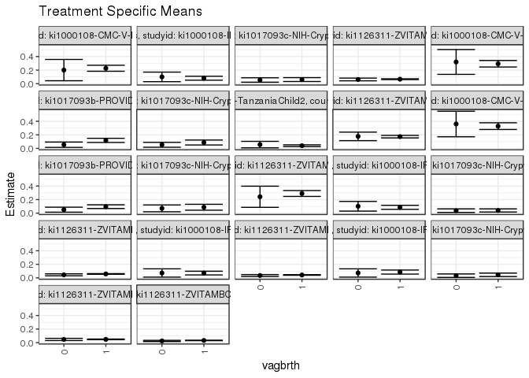

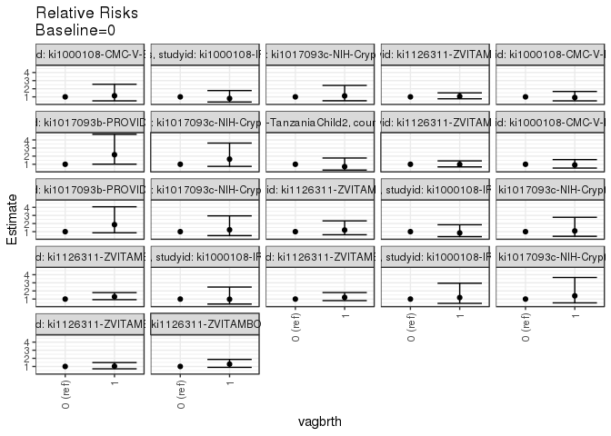

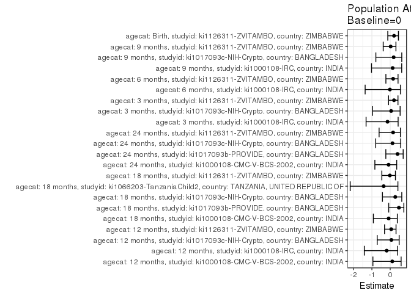

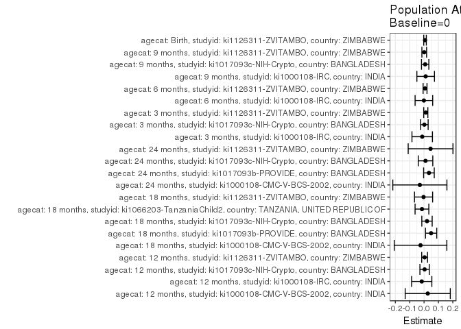

## Results Table

### Parameter: TSM

| agecat | studyid | country | intervention_level | baseline_level | estimate | ci_lower | ci_upper |
| --- | --- | --- | --- | --- | --- | --- | --- |
| Birth | ki1126311-ZVITAMBO | ZIMBABWE | 0 | NA | 0.0249570 | 0.0159875 | 0.0339265 |
| Birth | ki1126311-ZVITAMBO | ZIMBABWE | 1 | NA | 0.0321810 | 0.0290937 | 0.0352682 |
| 3 months | ki1000108-IRC | INDIA | 0 | NA | 0.1014493 | 0.0301223 | 0.1727762 |
| 3 months | ki1000108-IRC | INDIA | 1 | NA | 0.0857988 | 0.0559047 | 0.1156929 |
| 3 months | ki1017093c-NIH-Crypto | BANGLADESH | 0 | NA | 0.0362694 | 0.0098649 | 0.0626740 |
| 3 months | ki1017093c-NIH-Crypto | BANGLADESH | 1 | NA | 0.0395683 | 0.0166283 | 0.0625084 |
| 3 months | ki1126311-ZVITAMBO | ZIMBABWE | 0 | NA | 0.0451694 | 0.0307506 | 0.0595881 |
| 3 months | ki1126311-ZVITAMBO | ZIMBABWE | 1 | NA | 0.0581312 | 0.0531048 | 0.0631575 |
| 6 months | ki1000108-IRC | INDIA | 0 | NA | 0.0724638 | 0.0112169 | 0.1337106 |
| 6 months | ki1000108-IRC | INDIA | 1 | NA | 0.0710059 | 0.0435916 | 0.0984202 |
| 6 months | ki1126311-ZVITAMBO | ZIMBABWE | 0 | NA | 0.0353607 | 0.0217460 | 0.0489754 |
| 6 months | ki1126311-ZVITAMBO | ZIMBABWE | 1 | NA | 0.0426805 | 0.0381119 | 0.0472491 |
| 9 months | ki1000108-IRC | INDIA | 0 | NA | 0.0724638 | 0.0112169 | 0.1337106 |
| 9 months | ki1000108-IRC | INDIA | 1 | NA | 0.0857988 | 0.0559047 | 0.1156929 |
| 9 months | ki1017093c-NIH-Crypto | BANGLADESH | 0 | NA | 0.0324324 | 0.0068774 | 0.0579874 |
| 9 months | ki1017093c-NIH-Crypto | BANGLADESH | 1 | NA | 0.0452830 | 0.0202212 | 0.0703449 |
| 9 months | ki1126311-ZVITAMBO | ZIMBABWE | 0 | NA | 0.0468750 | 0.0304981 | 0.0632519 |
| 9 months | ki1126311-ZVITAMBO | ZIMBABWE | 1 | NA | 0.0482135 | 0.0431838 | 0.0532433 |
| 12 months | ki1000108-CMC-V-BCS-2002 | INDIA | 0 | NA | 0.2000000 | 0.0429894 | 0.3570106 |
| 12 months | ki1000108-CMC-V-BCS-2002 | INDIA | 1 | NA | 0.2274052 | 0.1829863 | 0.2718242 |
| 12 months | ki1000108-IRC | INDIA | 0 | NA | 0.1000000 | 0.0296351 | 0.1703649 |
| 12 months | ki1000108-IRC | INDIA | 1 | NA | 0.0803571 | 0.0512543 | 0.1094600 |
| 12 months | ki1017093c-NIH-Crypto | BANGLADESH | 0 | NA | 0.0540541 | 0.0214334 | 0.0866747 |
| 12 months | ki1017093c-NIH-Crypto | BANGLADESH | 1 | NA | 0.0603774 | 0.0316681 | 0.0890866 |
| 12 months | ki1126311-ZVITAMBO | ZIMBABWE | 0 | NA | 0.0618182 | 0.0416902 | 0.0819462 |
| 12 months | ki1126311-ZVITAMBO | ZIMBABWE | 1 | NA | 0.0657873 | 0.0595864 | 0.0719882 |
| 18 months | ki1000108-CMC-V-BCS-2002 | INDIA | 0 | NA | 0.3200000 | 0.1368964 | 0.5031036 |
| 18 months | ki1000108-CMC-V-BCS-2002 | INDIA | 1 | NA | 0.2936047 | 0.2454139 | 0.3417954 |
| 18 months | ki1017093b-PROVIDE | BANGLADESH | 0 | NA | 0.0542636 | 0.0151357 | 0.0933914 |
| 18 months | ki1017093b-PROVIDE | BANGLADESH | 1 | NA | 0.1182033 | 0.0874090 | 0.1489976 |
| 18 months | ki1017093c-NIH-Crypto | BANGLADESH | 0 | NA | 0.0533333 | 0.0173275 | 0.0893391 |
| 18 months | ki1017093c-NIH-Crypto | BANGLADESH | 1 | NA | 0.0869565 | 0.0504935 | 0.1234196 |
| 18 months | ki1066203-TanzaniaChild2 | TANZANIA, UNITED REPUBLIC OF | 0 | NA | 0.0561798 | 0.0083154 | 0.1040442 |
| 18 months | ki1066203-TanzaniaChild2 | TANZANIA, UNITED REPUBLIC OF | 1 | NA | 0.0398633 | 0.0269160 | 0.0528106 |
| 18 months | ki1126311-ZVITAMBO | ZIMBABWE | 0 | NA | 0.1773050 | 0.1142460 | 0.2403639 |
| 18 months | ki1126311-ZVITAMBO | ZIMBABWE | 1 | NA | 0.1734365 | 0.1545879 | 0.1922851 |
| 24 months | ki1000108-CMC-V-BCS-2002 | INDIA | 0 | NA | 0.3600000 | 0.1715900 | 0.5484100 |
| 24 months | ki1000108-CMC-V-BCS-2002 | INDIA | 1 | NA | 0.3285303 | 0.2790458 | 0.3780147 |
| 24 months | ki1017093b-PROVIDE | BANGLADESH | 0 | NA | 0.0510949 | 0.0141916 | 0.0879981 |
| 24 months | ki1017093b-PROVIDE | BANGLADESH | 1 | NA | 0.0954545 | 0.0679748 | 0.1229342 |
| 24 months | ki1017093c-NIH-Crypto | BANGLADESH | 0 | NA | 0.0707071 | 0.0201159 | 0.1212983 |
| 24 months | ki1017093c-NIH-Crypto | BANGLADESH | 1 | NA | 0.0869565 | 0.0433483 | 0.1305648 |
| 24 months | ki1126311-ZVITAMBO | ZIMBABWE | 0 | NA | 0.2413793 | 0.0854619 | 0.3972967 |
| 24 months | ki1126311-ZVITAMBO | ZIMBABWE | 1 | NA | 0.2897862 | 0.2464028 | 0.3331696 |

### Parameter: E(Y)

| agecat | studyid | country | intervention_level | baseline_level | estimate | ci_lower | ci_upper |
| --- | --- | --- | --- | --- | --- | --- | --- |
| Birth | ki1126311-ZVITAMBO | ZIMBABWE | NA | NA | 0.0315690 | 0.0315353 | 0.0316026 |
| 3 months | ki1000108-IRC | INDIA | NA | NA | 0.0884521 | 0.0878809 | 0.0890233 |
| 3 months | ki1017093c-NIH-Crypto | BANGLADESH | NA | NA | 0.0382166 | 0.0380699 | 0.0383632 |
| 3 months | ki1126311-ZVITAMBO | ZIMBABWE | NA | NA | 0.0569988 | 0.0569237 | 0.0570739 |
| 6 months | ki1000108-IRC | INDIA | NA | NA | 0.0712531 | 0.0711999 | 0.0713063 |
| 6 months | ki1126311-ZVITAMBO | ZIMBABWE | NA | NA | 0.0420515 | 0.0420072 | 0.0420959 |
| 9 months | ki1000108-IRC | INDIA | NA | NA | 0.0835381 | 0.0830514 | 0.0840248 |
| 9 months | ki1017093c-NIH-Crypto | BANGLADESH | NA | NA | 0.0400000 | 0.0394152 | 0.0405848 |
| 9 months | ki1126311-ZVITAMBO | ZIMBABWE | NA | NA | 0.0481009 | 0.0480926 | 0.0481093 |
| 12 months | ki1000108-CMC-V-BCS-2002 | INDIA | NA | NA | 0.2255435 | 0.2248379 | 0.2262490 |
| 12 months | ki1000108-IRC | INDIA | NA | NA | 0.0837438 | 0.0830212 | 0.0844665 |
| 12 months | ki1017093c-NIH-Crypto | BANGLADESH | NA | NA | 0.0577778 | 0.0574900 | 0.0580656 |
| 12 months | ki1126311-ZVITAMBO | ZIMBABWE | NA | NA | 0.0654611 | 0.0654349 | 0.0654872 |
| 18 months | ki1000108-CMC-V-BCS-2002 | INDIA | NA | NA | 0.2953930 | 0.2947152 | 0.2960707 |
| 18 months | ki1017093b-PROVIDE | BANGLADESH | NA | NA | 0.1032609 | 0.1010016 | 0.1055201 |
| 18 months | ki1017093c-NIH-Crypto | BANGLADESH | NA | NA | 0.0736842 | 0.0720296 | 0.0753388 |
| 18 months | ki1066203-TanzaniaChild2 | TANZANIA, UNITED REPUBLIC OF | NA | NA | 0.0413650 | 0.0410676 | 0.0416625 |
| 18 months | ki1126311-ZVITAMBO | ZIMBABWE | NA | NA | 0.1737589 | 0.1737079 | 0.1738098 |
| 24 months | ki1000108-CMC-V-BCS-2002 | INDIA | NA | NA | 0.3306452 | 0.3298434 | 0.3314469 |
| 24 months | ki1017093b-PROVIDE | BANGLADESH | NA | NA | 0.0849220 | 0.0833805 | 0.0864635 |
| 24 months | ki1017093c-NIH-Crypto | BANGLADESH | NA | NA | 0.0807692 | 0.0798083 | 0.0817302 |
| 24 months | ki1126311-ZVITAMBO | ZIMBABWE | NA | NA | 0.2866667 | 0.2855673 | 0.2877661 |

### Parameter: RR

| agecat | studyid | country | intervention_level | baseline_level | estimate | ci_lower | ci_upper |
| --- | --- | --- | --- | --- | --- | --- | --- |
| Birth | ki1126311-ZVITAMBO | ZIMBABWE | 0 | 0 | 1.0000000 | 1.0000000 | 1.000000 |
| Birth | ki1126311-ZVITAMBO | ZIMBABWE | 1 | 0 | 1.2894585 | 0.8889094 | 1.870498 |
| 3 months | ki1000108-IRC | INDIA | 0 | 0 | 1.0000000 | 1.0000000 | 1.000000 |
| 3 months | ki1000108-IRC | INDIA | 1 | 0 | 0.8457312 | 0.3858792 | 1.853588 |
| 3 months | ki1017093c-NIH-Crypto | BANGLADESH | 0 | 0 | 1.0000000 | 1.0000000 | 1.000000 |
| 3 months | ki1017093c-NIH-Crypto | BANGLADESH | 1 | 0 | 1.0909558 | 0.4301585 | 2.766851 |
| 3 months | ki1126311-ZVITAMBO | ZIMBABWE | 0 | 0 | 1.0000000 | 1.0000000 | 1.000000 |
| 3 months | ki1126311-ZVITAMBO | ZIMBABWE | 1 | 0 | 1.2869592 | 0.9245609 | 1.791406 |
| 6 months | ki1000108-IRC | INDIA | 0 | 0 | 1.0000000 | 1.0000000 | 1.000000 |
| 6 months | ki1000108-IRC | INDIA | 1 | 0 | 0.9798817 | 0.3869206 | 2.481564 |
| 6 months | ki1126311-ZVITAMBO | ZIMBABWE | 0 | 0 | 1.0000000 | 1.0000000 | 1.000000 |
| 6 months | ki1126311-ZVITAMBO | ZIMBABWE | 1 | 0 | 1.2070044 | 0.8093821 | 1.799965 |
| 9 months | ki1000108-IRC | INDIA | 0 | 0 | 1.0000000 | 1.0000000 | 1.000000 |
| 9 months | ki1000108-IRC | INDIA | 1 | 0 | 1.1840237 | 0.4745983 | 2.953892 |
| 9 months | ki1017093c-NIH-Crypto | BANGLADESH | 0 | 0 | 1.0000000 | 1.0000000 | 1.000000 |
| 9 months | ki1017093c-NIH-Crypto | BANGLADESH | 1 | 0 | 1.3962264 | 0.5330604 | 3.657087 |
| 9 months | ki1126311-ZVITAMBO | ZIMBABWE | 0 | 0 | 1.0000000 | 1.0000000 | 1.000000 |
| 9 months | ki1126311-ZVITAMBO | ZIMBABWE | 1 | 0 | 1.0285550 | 0.7142930 | 1.481081 |
| 12 months | ki1000108-CMC-V-BCS-2002 | INDIA | 0 | 0 | 1.0000000 | 1.0000000 | 1.000000 |
| 12 months | ki1000108-CMC-V-BCS-2002 | INDIA | 1 | 0 | 1.1370262 | 0.5063274 | 2.553345 |
| 12 months | ki1000108-IRC | INDIA | 0 | 0 | 1.0000000 | 1.0000000 | 1.000000 |
| 12 months | ki1000108-IRC | INDIA | 1 | 0 | 0.8035714 | 0.3641925 | 1.773038 |
| 12 months | ki1017093c-NIH-Crypto | BANGLADESH | 0 | 0 | 1.0000000 | 1.0000000 | 1.000000 |
| 12 months | ki1017093c-NIH-Crypto | BANGLADESH | 1 | 0 | 1.1169811 | 0.5180557 | 2.408326 |
| 12 months | ki1126311-ZVITAMBO | ZIMBABWE | 0 | 0 | 1.0000000 | 1.0000000 | 1.000000 |
| 12 months | ki1126311-ZVITAMBO | ZIMBABWE | 1 | 0 | 1.0642068 | 0.7582524 | 1.493614 |
| 18 months | ki1000108-CMC-V-BCS-2002 | INDIA | 0 | 0 | 1.0000000 | 1.0000000 | 1.000000 |
| 18 months | ki1000108-CMC-V-BCS-2002 | INDIA | 1 | 0 | 0.9175145 | 0.5059279 | 1.663939 |
| 18 months | ki1017093b-PROVIDE | BANGLADESH | 0 | 0 | 1.0000000 | 1.0000000 | 1.000000 |
| 18 months | ki1017093b-PROVIDE | BANGLADESH | 1 | 0 | 2.1783181 | 1.0119336 | 4.689112 |
| 18 months | ki1017093c-NIH-Crypto | BANGLADESH | 0 | 0 | 1.0000000 | 1.0000000 | 1.000000 |
| 18 months | ki1017093c-NIH-Crypto | BANGLADESH | 1 | 0 | 1.6304348 | 0.7364680 | 3.609549 |
| 18 months | ki1066203-TanzaniaChild2 | TANZANIA, UNITED REPUBLIC OF | 0 | 0 | 1.0000000 | 1.0000000 | 1.000000 |
| 18 months | ki1066203-TanzaniaChild2 | TANZANIA, UNITED REPUBLIC OF | 1 | 0 | 0.7095672 | 0.2851058 | 1.765961 |
| 18 months | ki1126311-ZVITAMBO | ZIMBABWE | 0 | 0 | 1.0000000 | 1.0000000 | 1.000000 |
| 18 months | ki1126311-ZVITAMBO | ZIMBABWE | 1 | 0 | 0.9781818 | 0.6743904 | 1.418821 |
| 24 months | ki1000108-CMC-V-BCS-2002 | INDIA | 0 | 0 | 1.0000000 | 1.0000000 | 1.000000 |
| 24 months | ki1000108-CMC-V-BCS-2002 | INDIA | 1 | 0 | 0.9125841 | 0.5293636 | 1.573228 |
| 24 months | ki1017093b-PROVIDE | BANGLADESH | 0 | 0 | 1.0000000 | 1.0000000 | 1.000000 |
| 24 months | ki1017093b-PROVIDE | BANGLADESH | 1 | 0 | 1.8681818 | 0.8585216 | 4.065248 |
| 24 months | ki1017093c-NIH-Crypto | BANGLADESH | 0 | 0 | 1.0000000 | 1.0000000 | 1.000000 |
| 24 months | ki1017093c-NIH-Crypto | BANGLADESH | 1 | 0 | 1.2298137 | 0.5133025 | 2.946492 |
| 24 months | ki1126311-ZVITAMBO | ZIMBABWE | 0 | 0 | 1.0000000 | 1.0000000 | 1.000000 |
| 24 months | ki1126311-ZVITAMBO | ZIMBABWE | 1 | 0 | 1.2005429 | 0.6186031 | 2.329932 |

### Parameter: PAR

| agecat | studyid | country | intervention_level | baseline_level | estimate | ci_lower | ci_upper |
| --- | --- | --- | --- | --- | --- | --- | --- |
| Birth | ki1126311-ZVITAMBO | ZIMBABWE | 0 | NA | 0.0066120 | -0.0023576 | 0.0155816 |
| 3 months | ki1000108-IRC | INDIA | 0 | NA | -0.0129972 | -0.0843264 | 0.0583320 |
| 3 months | ki1017093c-NIH-Crypto | BANGLADESH | 0 | NA | 0.0019471 | -0.0244578 | 0.0283521 |
| 3 months | ki1126311-ZVITAMBO | ZIMBABWE | 0 | NA | 0.0118294 | -0.0025896 | 0.0262484 |
| 6 months | ki1000108-IRC | INDIA | 0 | NA | -0.0012107 | -0.0624576 | 0.0600362 |
| 6 months | ki1126311-ZVITAMBO | ZIMBABWE | 0 | NA | 0.0066909 | -0.0069239 | 0.0203056 |
| 9 months | ki1000108-IRC | INDIA | 0 | NA | 0.0110743 | -0.0501745 | 0.0723231 |
| 9 months | ki1017093c-NIH-Crypto | BANGLADESH | 0 | NA | 0.0075676 | -0.0179941 | 0.0331292 |
| 9 months | ki1126311-ZVITAMBO | ZIMBABWE | 0 | NA | 0.0012259 | -0.0151510 | 0.0176029 |
| 12 months | ki1000108-CMC-V-BCS-2002 | INDIA | 0 | NA | 0.0255435 | -0.1314687 | 0.1825557 |
| 12 months | ki1000108-IRC | INDIA | 0 | NA | -0.0162562 | -0.0866247 | 0.0541124 |
| 12 months | ki1017093c-NIH-Crypto | BANGLADESH | 0 | NA | 0.0037237 | -0.0288982 | 0.0363456 |
| 12 months | ki1126311-ZVITAMBO | ZIMBABWE | 0 | NA | 0.0036429 | -0.0164851 | 0.0237709 |
| 18 months | ki1000108-CMC-V-BCS-2002 | INDIA | 0 | NA | -0.0246070 | -0.2077119 | 0.1584978 |
| 18 months | ki1017093b-PROVIDE | BANGLADESH | 0 | NA | 0.0489973 | 0.0098043 | 0.0881903 |
| 18 months | ki1017093c-NIH-Crypto | BANGLADESH | 0 | NA | 0.0203509 | -0.0156929 | 0.0563947 |
| 18 months | ki1066203-TanzaniaChild2 | TANZANIA, UNITED REPUBLIC OF | 0 | NA | -0.0148147 | -0.0626800 | 0.0330506 |
| 18 months | ki1126311-ZVITAMBO | ZIMBABWE | 0 | NA | -0.0035461 | -0.0666051 | 0.0595129 |
| 24 months | ki1000108-CMC-V-BCS-2002 | INDIA | 0 | NA | -0.0293548 | -0.2177665 | 0.1590568 |
| 24 months | ki1017093b-PROVIDE | BANGLADESH | 0 | NA | 0.0338271 | -0.0031083 | 0.0707625 |
| 24 months | ki1017093c-NIH-Crypto | BANGLADESH | 0 | NA | 0.0100622 | -0.0405382 | 0.0606625 |
| 24 months | ki1126311-ZVITAMBO | ZIMBABWE | 0 | NA | 0.0452874 | -0.1106339 | 0.2012086 |

### Parameter: PAF

| agecat | studyid | country | intervention_level | baseline_level | estimate | ci_lower | ci_upper |
| --- | --- | --- | --- | --- | --- | --- | --- |
| Birth | ki1126311-ZVITAMBO | ZIMBABWE | 0 | NA | 0.2094462 | -0.1324450 | 0.4481186 |
| 3 months | ki1000108-IRC | INDIA | 0 | NA | -0.1469404 | -1.3168471 | 0.4322144 |
| 3 months | ki1017093c-NIH-Crypto | BANGLADESH | 0 | NA | 0.0509499 | -0.9654637 | 0.5417386 |
| 3 months | ki1126311-ZVITAMBO | ZIMBABWE | 0 | NA | 0.2075379 | -0.0904686 | 0.4241043 |
| 6 months | ki1000108-IRC | INDIA | 0 | NA | -0.0169915 | -1.3680229 | 0.5632341 |
| 6 months | ki1126311-ZVITAMBO | ZIMBABWE | 0 | NA | 0.1591108 | -0.2358133 | 0.4278305 |
| 9 months | ki1000108-IRC | INDIA | 0 | NA | 0.1325661 | -1.0198241 | 0.6274717 |
| 9 months | ki1017093c-NIH-Crypto | BANGLADESH | 0 | NA | 0.1891892 | -0.7831129 | 0.6313110 |
| 9 months | ki1126311-ZVITAMBO | ZIMBABWE | 0 | NA | 0.0254867 | -0.3820353 | 0.3128423 |
| 12 months | ki1000108-CMC-V-BCS-2002 | INDIA | 0 | NA | 0.1132530 | -0.9442253 | 0.5955612 |
| 12 months | ki1000108-IRC | INDIA | 0 | NA | -0.1941176 | -1.4135750 | 0.4092096 |
| 12 months | ki1017093c-NIH-Crypto | BANGLADESH | 0 | NA | 0.0644491 | -0.7106662 | 0.4883540 |
| 12 months | ki1126311-ZVITAMBO | ZIMBABWE | 0 | NA | 0.0556496 | -0.3077948 | 0.3180906 |
| 18 months | ki1000108-CMC-V-BCS-2002 | INDIA | 0 | NA | -0.0833028 | -0.9197937 | 0.3887130 |
| 18 months | ki1017093b-PROVIDE | BANGLADESH | 0 | NA | 0.4745002 | -0.0811195 | 0.7445703 |
| 18 months | ki1017093c-NIH-Crypto | BANGLADESH | 0 | NA | 0.2761905 | -0.4222715 | 0.6316454 |
| 18 months | ki1066203-TanzaniaChild2 | TANZANIA, UNITED REPUBLIC OF | 0 | NA | -0.3581461 | -2.1839954 | 0.4206773 |
| 18 months | ki1126311-ZVITAMBO | ZIMBABWE | 0 | NA | -0.0204082 | -0.4562365 | 0.2849837 |
| 24 months | ki1000108-CMC-V-BCS-2002 | INDIA | 0 | NA | -0.0887805 | -0.8375347 | 0.3548732 |
| 24 months | ki1017093b-PROVIDE | BANGLADESH | 0 | NA | 0.3983316 | -0.2391536 | 0.7078612 |
| 24 months | ki1017093c-NIH-Crypto | BANGLADESH | 0 | NA | 0.1245791 | -0.7906033 | 0.5720092 |
| 24 months | ki1126311-ZVITAMBO | ZIMBABWE | 0 | NA | 0.1579791 | -0.6064139 | 0.5586448 |